# INFSCI 2595 Spring 2023 Homework: 02

Assigned January 18, 2023; Due: January 25, 2023

Peng Yuan

Submission time: January 25, 2023 at 11:00PM EST

#### Collaborators

Include the names of your collaborators here.

## Overview

This assignment is focused on fitting and comparing regression models. Your task is to fit 9 polynomial models from degree 1 (linear relationship) to degree 9 (a 9th degree polynomial). You will interpret behavior through analyzing the coefficient estimates and by visualizing predictions from the models. You must select the best performing model and you will do so several different ways. You will first consider performance on the training set alone, then use a single train/test split, and finally using 5-fold cross-validation.

You will work with 3 different data sets, but all 3 data sets were generated from the same **data generating process**. These 3 different versions of the data will allow you consider the influence of sample size (low vs high) and uncontrollable variation or noise (low vs high) on the model selection process.

**IMPORTANT**: You are working with 3 data sets in this assignment. This does not mean you must always have multiple “versions” of a data set to complete a machine learning application. This assignment is constructed so that you will see the relationship between sample size and noise on the ability to learn and identify appropriate levels of complexity. The data in this assignment are synthetic data created specifically for this assignment.

**IMPORTANT**: The RMarkdown assumes you have downloaded the 3 data sets (CSV files) to the same directory you saved the template Rmarkdown file. If you do not have the 3 CSV files in the correct location, the data will not be loaded correctly.

### IMPORTANT!!!

Certain code chunks are created for you. Each code chunk has `eval=FALSE` set in the chunk options. You **MUST** change it to be `eval=TRUE` in order for the code chunks to be evaluated when rendering the document.

You are free to add more code chunks if you would like.

## Load packages

The `tidyverse` is loaded in for you in the code chunk below. The visualization package, `ggplot2`, and the data manipulation package, `dplyr`, are part of the “larger” `tidyverse`.

```r
library(tidyverse)
```

The `modelr` package is loaded in for you in the code chunk below. You may use functions from `modelr` to calculate performance metrics for your models.

```r
library(modelr)
```

This assignment also uses functions from the `coefplot` package and uses the major functions from the `caret` package. Those packages will be loaded when necessary later in the assignment.

## Problem 01

A data set is loaded for you in the code chunk below. The data are assigned to the `df_low_high` object. The naming convention of this variable represents that the data were generated with low sample size and high noise. Thus, you will begin your predictive modeling or *supervised learning* task with data that are known to be noisy.

```r
path_low_high <- 'hw02_lowsize_highnoise.csv'

df_low_high <- readr::read_csv(path_low_high, col_names = TRUE)
```

A glimpse of the data are provided for you below. The variable `x` is the input and the variable `y` is the response. Your task is to predict `y` as a function of `x` using various polynomial models. As stated before, the data in Problem 01 are the “noisy” data.

```r
df_low_high %>% glimpse()
```

```
## Rows: 40
## Columns: 2
## $ x <dbl> -0.11464944, 0.22502931, 0.37356406, -2.34241739, 1.15847408, 0.3443…
## $ y <dbl> 2.9964689, -0.9068521, -3.9404374, 5.0813180, -6.8506793, 2.5897728,…
```

### 1a)

It is always best to explore the data before fitting models. For this assignment, all you are required to do is visualize the relationship between the output and input with a scatter plot.

**Use ggplot2 to create a scatter plot between the input, `x`, and the response, `y`. The scatter plot is created with the `geom_point()` geom. Manually set the marker size to be 3 within the `geom_point()` geom.**

**Does the relationship between the input and response appear to be linear or non-linear?**

#### SOLUTION

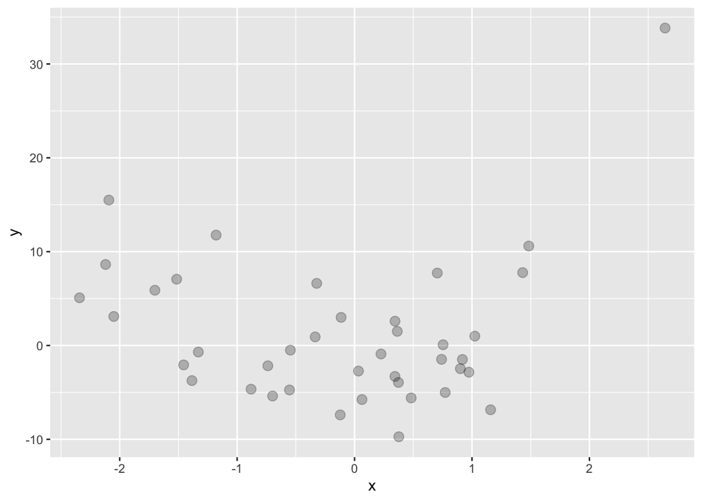

```r
### your code here
df_low_high %>%
    ggplot(mapping = aes(x = x, y = y)) +
    geom_point(alpha = 0.25, size = 3)
```

**Is the relationship linear or non-linear?**

### 1b)

It’s time fit the models! You must fit 9 models using the `lm()` function and the formula interface. You used both the `lm()` function and the formula interface in the previous assignment. However, this time you must specify the appropriate polynomial features. You are not allowed to use any functions to generate the polynomials. You **MUST** manually type each polynomial feature in the formulas!

**Complete the code chunks below by calling the `lm()` function with the appropriate formula and correctly specifying the `data` argument. The result are assigned to variable names defined for you in each of the code chunks. The variable names and the comment within each code chunk specifies the polynomial degree you should use.**

**You must use the complete data for fitting the models.**

#### SOLUTION

```r
### linear relationship (degree 1)
fit_lm_1 <- lm(y ~ x, as.data.frame(df_low_high))

fit_lm_1
```

```
##
## Call:
## lm(formula = y ~ x, data = as.data.frame(df_low_high))
##
## Coefficients:
## (Intercept)            x
##      1.2769       0.3444
```

```r
### quadratic relationship (degree 2)
fit_lm_2 <- lm(y ~ x + I(x^2), as.data.frame(df_low_high))

fit_lm_2
```

```
##
## Call:
## lm(formula = y ~ x + I(x^2), data = as.data.frame(df_low_high))
##
## Coefficients:
## (Intercept)            x       I(x^2)
##      -3.462        1.862        3.731
```

```r
### cubic relationship (degree 3)
fit_lm_3 <- lm(y ~ x + I(x^2) + I(x^3), as.data.frame(df_low_high))

fit_lm_3
```

```
##
## Call:
## lm(formula = y ~ x + I(x^2) + I(x^3), data = as.data.frame(df_low_high))
##
## Coefficients:
## (Intercept)            x       I(x^2)       I(x^3)
##     -2.9936      -0.8654       3.5211       0.7846
```

```r
### degree 4
fit_lm_4 <- lm(y ~ x + I(x^2) + I(x^3) + I(x^4), as.data.frame(df_low_high))

fit_lm_4
```

```
##
## Call:
## lm(formula = y ~ x + I(x^2) + I(x^3) + I(x^4), data = as.data.frame(df_low_high))
##
## Coefficients:
## (Intercept)            x       I(x^2)       I(x^3)       I(x^4)
##     -2.7717      -0.8328       3.0563       0.7460       0.0825
```

```r
### degree 5
fit_lm_5 <- lm(y ~ x + I(x^2) + I(x^3) + I(x^4) + I(x^5), as.data.frame(df_low_high))

fit_lm_5
```

```
##
## Call:
## lm(formula = y ~ x + I(x^2) + I(x^3) + I(x^4) + I(x^5), data = as.data.frame(df_low_high))
##
## Coefficients:
## (Intercept)            x       I(x^2)       I(x^3)       I(x^4)       I(x^5)
##    -2.76706     -0.93701      3.05965      0.84420      0.08651     -0.01386
```

```r
### degree 6
fit_lm_6 <-lm(y ~ x + I(x^2) + I(x^3) + I(x^4) + I(x^5) + I(x^6), as.data.frame(df_low_high))

fit_lm_6
```

```
##
## Call:
## lm(formula = y ~ x + I(x^2) + I(x^3) + I(x^4) + I(x^5) + I(x^6),
##     data = as.data.frame(df_low_high))
##
## Coefficients:
## (Intercept)            x       I(x^2)       I(x^3)       I(x^4)       I(x^5)
##    -1.43218     -1.54231     -2.99550      1.62111      3.78775     -0.00956
##      I(x^6)
##    -0.44929
```

```r
### degree 7
fit_lm_7 <-lm(y ~ x + I(x^2) + I(x^3) + I(x^4) + I(x^5) + I(x^6) + I(x^7), as.data.frame(df_low_high))

fit_lm_7
```

```
##
## Call:
## lm(formula = y ~ x + I(x^2) + I(x^3) + I(x^4) + I(x^5) + I(x^6) +
##     I(x^7), data = as.data.frame(df_low_high))
##
## Coefficients:
## (Intercept)            x       I(x^2)       I(x^3)       I(x^4)       I(x^5)
##    -1.34138     -0.84579     -3.62807      0.25342      4.20437      0.62591
##      I(x^6)       I(x^7)
##    -0.48743     -0.06828
```

```r
### degree 8
fit_lm_8 <- lm(y ~ x + I(x^2) + I(x^3) + I(x^4) + I(x^5) + I(x^6) + I(x^7) + I(x^8), as.data.frame(df_low_high))

fit_lm_8
```

```
##
## Call:
## lm(formula = y ~ x + I(x^2) + I(x^3) + I(x^4) + I(x^5) + I(x^6) +
##     I(x^7) + I(x^8), data = as.data.frame(df_low_high))
##
## Coefficients:
## (Intercept)            x       I(x^2)       I(x^3)       I(x^4)       I(x^5)
##     -2.1119       1.4413       2.3291      -5.8503      -3.3330       3.7144
##      I(x^6)       I(x^7)       I(x^8)
##      2.4270      -0.3726      -0.2870
```

```r
### degree 9
fit_lm_9 <- lm(y ~ x + I(x^2) + I(x^3) + I(x^4) + I(x^5) + I(x^6) + I(x^7) + I(x^8) + I(x^9), as.data.frame(df_low_high))

fit_lm_9
```

```
##
## Call:
## lm(formula = y ~ x + I(x^2) + I(x^3) + I(x^4) + I(x^5) + I(x^6) +
##     I(x^7) + I(x^8) + I(x^9), data = as.data.frame(df_low_high))
##
## Coefficients:
## (Intercept)            x       I(x^2)       I(x^3)       I(x^4)       I(x^5)
##     -2.5595      -0.3716       7.8702       1.6160     -12.5569      -4.3762
##      I(x^6)       I(x^7)       I(x^8)       I(x^9)
##      6.4072       2.5762      -0.6699      -0.2825
```

### 1c)

You fit 9 regression models, it’s time to pick the best one! You will initially make your selection based on the training set performance.

**Calculate the training set RMSE for each model. It is up to you as to how to organize the RMSE values and display the results. Bare minimum, you must display the RMSE for each model. You are only allowed to use functions from lecture.**

#### SOLUTION

```r
### add as many code chunks as necessary
modelr::rmse(fit_lm_1,df_low_high)
```

```
## [1] 7.717771
```

```r
modelr::rmse(fit_lm_2,df_low_high)
```

```
## [1] 4.942079
```

```r
modelr::rmse(fit_lm_3,df_low_high)
```

```
## [1] 4.581047
```

```r
modelr::rmse(fit_lm_4,df_low_high)
```

```
## [1] 4.575364
```

```r
modelr::rmse(fit_lm_5,df_low_high)
```

```
## [1] 4.575193
```

```r
modelr::rmse(fit_lm_6,df_low_high)
```

```
## [1] 4.379204
```

```r
modelr::rmse(fit_lm_7,df_low_high)
```

```
## [1] 4.37398
```

```r
modelr::rmse(fit_lm_8,df_low_high)
```

```
## [1] 4.31856
```

```r
modelr::rmse(fit_lm_9,df_low_high)
```

```
## [1] 4.279992
```

### 1d)

There are many different performance metrics we can use to compare models. For this problem, we will consider R-squared in addition to the RMSE.

**Calculate the training set R-squared for each model. It is up to you as to how to organize the R-squared values and display the results. Bare minimum, you must display the R-squared for each model. You are only allowed to use functions from lecture.**

#### SOLUTION

```r
### add as many code chunks as necessary
modelr::rsquare(fit_lm_1,df_low_high)
```

```
## [1] 0.002595816
```

```r
modelr::rsquare(fit_lm_2,df_low_high)
```

```
## [1] 0.5910155
```

```r
modelr::rsquare(fit_lm_3,df_low_high)
```

```
## [1] 0.6485876
```

```r
modelr::rsquare(fit_lm_4,df_low_high)
```

```
## [1] 0.649459
```

```r
modelr::rsquare(fit_lm_5,df_low_high)
```

```
## [1] 0.6494853
```

```r
modelr::rsquare(fit_lm_6,df_low_high)
```

```
## [1] 0.6788723
```

```r
modelr::rsquare(fit_lm_7,df_low_high)
```

```
## [1] 0.679638
```

```r
modelr::rsquare(fit_lm_8,df_low_high)
```

```
## [1] 0.6877048
```

```r
modelr::rsquare(fit_lm_9,df_low_high)
```

```
## [1] 0.6932579
```

### 1e)

**Which model is the best according to the training set performance metrics? Why did you make the selection that you did? Do the two performance metrics agree on the best model?**

#### SOLUTION

**The result of R-squared shows that fit_lm_9 is the greatest and it’s RMSE value is the lowest,so fit_lm_9 is considered to be the best model.**

### 1f)

Let’s dive deeper into a few of the models. You will visualize the coefficient summaries for three models to examine the number of statistically significant features and to get an idea of the uncertainty on the coefficients. Regardless of your answer to Problem 1e), you must examine the coefficients for the quadratic model (degree 2), the 6th degree model, and the 9th degree model.

You used the `coefplot()` function from the `coefplot` package to visualize model coefficient summaries in the previous assignment. You could call `coefplot::coefplot()` three different times, one for each model. However, the `coefplot` package has a useful “helper” function dedicated to visualizing the coefficients across multiple models. This function is named `coefplot::multiplot()`. The `coefplot::multiplot()` syntax is similar to `coefplot::coefplot()`. You pass in the model objects as arguments to the function. You must separate each model with a comman, `,`, within the function call. The `coefplot::multiplot()` function takes care of everything for you.

**Visualize the coefficient summaries for the quadratic (degree 2), 6th degree, and 9th degree polynomial models using the `coefplot::multiplot()` function.**

**You do NOT need to load the `coefplot` package. The `::` operator allows accessing the function `multiplot()` from within the `coefplot` library.**

#### SOLUTION

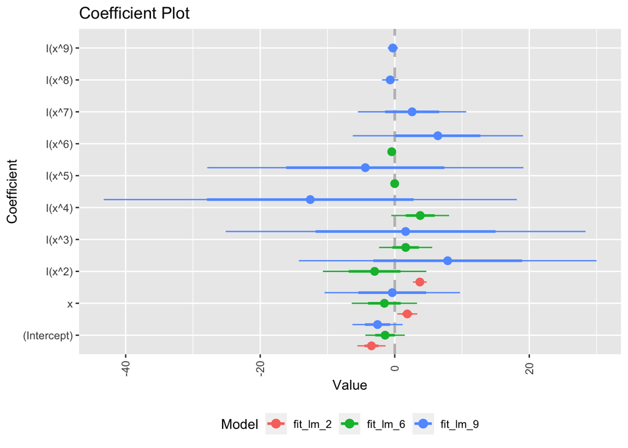

```r
### add your code here
coefplot::multiplot(fit_lm_2,fit_lm_6,fit_lm_9)
```

### 1g)

Some of the coefficients are present in all three models displayed in the figure from Problem 1f), while a few of the coefficients are only present in one of the models. Let’s look closely at the previous figure to try and interpret the model behavior.

**Are the coefficient estimates similar for those coefficients present in at least 2 of the models visualized in the previous figure?**

**Is the level or amount of uncertainty associated with the coefficients consistent across the three models?**

#### SOLUTION

**<1> For uncertainty, the inaccuracy of model 9 is the highest, because his line is the longest, which means that he may have more uncertainty values. Model 2 is the most accurate**

**<2> The models 6 and 9 lack coefficient because their lines intersect with 0, which indicates that it is difficult to judge their results. And the results of model 2 are more clear.**

## Problem 02

We discussed in lecture the importance of visualizing predictive model trends. This is an important and useful way of interpreting model behavior because it allows us to “see” what the model “thinks” happens at input values **not** present in the original training set. Creating such visualizations requires creating a new data set. Such data sets can require careful planning when there are dozens to hundreds of inputs. However, our present application has a single input and thus it is easy to define a meaningful *input grid* to support visualizing trends.

### 2a)

You must create the input grid to support visualization by defining a variable `x` within a data.frame (tibble) that consists of 201 evenly spaced points between the training set minimum and maximum values.

**The code chunk below is started for you. The `tibble::tibble()` function defines a tibble object. The data variable `x` is assigned within that tibble. You must complete that line of code by using an appropriate function which creates a sequence of values from a lower bound to an upper bound. You must use 201 evenly spaced points.**

**The lower bound must equal the input training set minimum value and the upper bound must equal the input training set maximum value.**

*HINT*: The lecture slides shows how to create this kind of object…

#### SOLUTION

```r
input_viz <- tibble::tibble(
  x = seq(min(df_low_high$x),max(df_low_high$x),length.out = 201)
)

input_viz
```

```
## # A tibble: 201 × 1
##        x
##    <dbl>
##  1 -2.34
##  2 -2.32
##  3 -2.29
##  4 -2.27
##  5 -2.24
##  6 -2.22
##  7 -2.19
##  8 -2.17
##  9 -2.14
## 10 -2.12
## # … with 191 more rows
```

If you created `input_viz` correctly, it should have 201 rows. The code chunk below checks the number of rows for you.

```r
input_viz %>% nrow()
```

```
## [1] 201
```

### 2b)

You must now make predictions for each model! In lecture, we discussed the importance including two types of uncertainty when we make predictions. However, since we are at the beginning of the semester, you are only responsible for making predictions of the **trend** or **average response**. Your returned predictions will therefore consist of numeric vectors.

**Complete the code chunks below by calling the appropriate function for making predictions for each model. The returned predictions are assigned must be assigned to the variables named in the code chunk below. The comments and the variable names specify which model should be used.**

*HINT*: Pay close attention to which data set you use when making the predictions…

#### SOLUTION

```r
### linear relationship (degree 1) predictions
viz_trend_1 <- predict(fit_lm_1,input_viz)

viz_trend_1
```

```
##         1         2         3         4         5         6         7         8
## 0.4700900 0.4786779 0.4872658 0.4958537 0.5044415 0.5130294 0.5216173 0.5302052
##         9        10        11        12        13        14        15        16
## 0.5387931 0.5473810 0.5559689 0.5645567 0.5731446 0.5817325 0.5903204 0.5989083
##        17        18        19        20        21        22        23        24
## 0.6074962 0.6160840 0.6246719 0.6332598 0.6418477 0.6504356 0.6590235 0.6676114
##        25        26        27        28        29        30        31        32
## 0.6761992 0.6847871 0.6933750 0.7019629 0.7105508 0.7191387 0.7277266 0.7363144
##        33        34        35        36        37        38        39        40
## 0.7449023 0.7534902 0.7620781 0.7706660 0.7792539 0.7878417 0.7964296 0.8050175
##        41        42        43        44        45        46        47        48
## 0.8136054 0.8221933 0.8307812 0.8393691 0.8479569 0.8565448 0.8651327 0.8737206
##        49        50        51        52        53        54        55        56
## 0.8823085 0.8908964 0.8994842 0.9080721 0.9166600 0.9252479 0.9338358 0.9424237
##        57        58        59        60        61        62        63        64
## 0.9510116 0.9595994 0.9681873 0.9767752 0.9853631 0.9939510 1.0025389 1.0111268
##        65        66        67        68        69        70        71        72
## 1.0197146 1.0283025 1.0368904 1.0454783 1.0540662 1.0626541 1.0712419 1.0798298
##        73        74        75        76        77        78        79        80
## 1.0884177 1.0970056 1.1055935 1.1141814 1.1227693 1.1313571 1.1399450 1.1485329
##        81        82        83        84        85        86        87        88
## 1.1571208 1.1657087 1.1742966 1.1828844 1.1914723 1.2000602 1.2086481 1.2172360
##        89        90        91        92        93        94        95        96
## 1.2258239 1.2344118 1.2429996 1.2515875 1.2601754 1.2687633 1.2773512 1.2859391
##        97        98        99       100       101       102       103       104
## 1.2945270 1.3031148 1.3117027 1.3202906 1.3288785 1.3374664 1.3460543 1.3546421
##       105       106       107       108       109       110       111       112
## 1.3632300 1.3718179 1.3804058 1.3889937 1.3975816 1.4061695 1.4147573 1.4233452
##       113       114       115       116       117       118       119       120
## 1.4319331 1.4405210 1.4491089 1.4576968 1.4662846 1.4748725 1.4834604 1.4920483
##       121       122       123       124       125       126       127       128
## 1.5006362 1.5092241 1.5178120 1.5263998 1.5349877 1.5435756 1.5521635 1.5607514
##       129       130       131       132       133       134       135       136
## 1.5693393 1.5779272 1.5865150 1.5951029 1.6036908 1.6122787 1.6208666 1.6294545
##       137       138       139       140       141       142       143       144
## 1.6380423 1.6466302 1.6552181 1.6638060 1.6723939 1.6809818 1.6895697 1.6981575
##       145       146       147       148       149       150       151       152
## 1.7067454 1.7153333 1.7239212 1.7325091 1.7410970 1.7496848 1.7582727 1.7668606
##       153       154       155       156       157       158       159       160
## 1.7754485 1.7840364 1.7926243 1.8012122 1.8098000 1.8183879 1.8269758 1.8355637
##       161       162       163       164       165       166       167       168
## 1.8441516 1.8527395 1.8613274 1.8699152 1.8785031 1.8870910 1.8956789 1.9042668
##       169       170       171       172       173       174       175       176
## 1.9128547 1.9214425 1.9300304 1.9386183 1.9472062 1.9557941 1.9643820 1.9729699
##       177       178       179       180       181       182       183       184
## 1.9815577 1.9901456 1.9987335 2.0073214 2.0159093 2.0244972 2.0330850 2.0416729
##       185       186       187       188       189       190       191       192
## 2.0502608 2.0588487 2.0674366 2.0760245 2.0846124 2.0932002 2.1017881 2.1103760
##       193       194       195       196       197       198       199       200
## 2.1189639 2.1275518 2.1361397 2.1447275 2.1533154 2.1619033 2.1704912 2.1790791
##       201
## 2.1876670
```

```r
### quadratic relationship (degree 2) predictions
viz_trend_2 <- predict(fit_lm_2,input_viz)

viz_trend_2
```

```
##            1            2            3            4            5            6
## 12.646704607 12.259663748 11.877261644 11.499498293 11.126373697 10.757887855
##            7            8            9           10           11           12
## 10.394040766 10.034832432  9.680262852  9.330332027  8.985039955  8.644386637
##           13           14           15           16           17           18
##  8.308372074  7.976996264  7.650259209  7.328160908  7.010701361  6.697880568
##           19           20           21           22           23           24
##  6.389698529  6.086155244  5.787250714  5.492984937  5.203357915  4.918369646
##           25           26           27           28           29           30
##  4.638020132  4.362309372  4.091237366  3.824804114  3.563009617  3.305853873
##           31           32           33           34           35           36
##  3.053336883  2.805458648  2.562219167  2.323618439  2.089656466  1.860333247
##           37           38           39           40           41           42
##  1.635648783  1.415603072  1.200196115  0.989427913  0.783298464  0.581807770
##           43           44           45           46           47           48
##  0.384955830  0.192742644  0.005168212 -0.177767466 -0.356064390 -0.529722560
##           49           50           51           52           53           54
## -0.698741975 -0.863122637 -1.022864544 -1.177967697 -1.328432096 -1.474257741
##           55           56           57           58           59           60
## -1.615444632 -1.751992769 -1.883902152 -2.011172780 -2.133804655 -2.251797775
##           61           62           63           64           65           66
## -2.365152141 -2.473867753 -2.577944611 -2.677382715 -2.772182065 -2.862342660
##           67           68           69           70           71           72
## -2.947864502 -3.028747589 -3.104991923 -3.176597502 -3.243564327 -3.305892398
##           73           74           75           76           77           78
## -3.363581715 -3.416632278 -3.465044086 -3.508817141 -3.547951441 -3.582446988
##           79           80           81           82           83           84
## -3.612303780 -3.637521818 -3.658101102 -3.674041632 -3.685343408 -3.692006430
##           85           86           87           88           89           90
## -3.694030697 -3.691416211 -3.684162970 -3.672270975 -3.655740226 -3.634570723
##           91           92           93           94           95           96
## -3.608762466 -3.578315455 -3.543229690 -3.503505170 -3.459141897 -3.410139869
##           97           98           99          100          101          102
## -3.356499087 -3.298219551 -3.235301261 -3.167744217 -3.095548419 -3.018713867
##          103          104          105          106          107          108
## -2.937240560 -2.851128500 -2.760377685 -2.664988116 -2.564959794 -2.460292717
##          109          110          111          112          113          114
## -2.350986886 -2.237042300 -2.118458961 -1.995236868 -1.867376020 -1.734876419
##          115          116          117          118          119          120
## -1.597738063 -1.455960953 -1.309545089 -1.158490471 -1.002797099 -0.842464972
```

[output cut: 13 more lines]

```
##  8.350867840  8.687472623  9.028716159  9.374598450  9.725119495 10.080279294
##          163          164          165          166          167          168
## 10.440077847 10.804515154 11.173591215 11.547306031 11.925659600 12.308651924
##          169          170          171          172          173          174
## 12.696283001 13.088552833 13.485461419 13.887008759 14.293194853 14.704019701
##          175          176          177          178          179          180
## 15.119483304 15.539585660 15.964326771 16.393706636 16.827725254 17.266382627
##          181          182          183          184          185          186
## 17.709678754 18.157613635 18.610187271 19.067399660 19.529250804 19.995740701
##          187          188          189          190          191          192
## 20.466869353 20.942636759 21.423042919 21.908087833 22.397771501 22.892093923
##          193          194          195          196          197          198
## 23.391055099 23.894655030 24.402893714 24.915771153 25.433287346 25.955442293
##          199          200          201
## 26.482235994 27.013668449 27.549739658
```

```r
### cubic relationship (degree 3) predictions
viz_trend_3 <- predict(fit_lm_3,input_viz)

viz_trend_3
```

```
##           1           2           3           4           5           6
##  8.26941941  8.15733136  8.04283895  7.92601516  7.80693297  7.68566533
##           7           8           9          10          11          12
##  7.56228523  7.43686564  7.30947952  7.18019986  7.04909961  6.91625177
##          13          14          15          16          17          18
##  6.78172929  6.64560515  6.50795232  6.36884377  6.22835249  6.08655143
##          19          20          21          22          23          24
##  5.94351357  5.79931188  5.65401934  5.50770891  5.36045358  5.21232630
##          25          26          27          28          29          30
##  5.06340006  4.91374782  4.76344257  4.61255726  4.46116487  4.30933838
##          31          32          33          34          35          36
##  4.15715076  4.00467497  3.85198400  3.69915080  3.54624837  3.39334966
##          37          38          39          40          41          42
##  3.24052765  3.08785531  2.93540562  2.78325154  2.63146605  2.48012212
##          43          44          45          46          47          48
##  2.32929272  2.17905083  2.02946942  1.88062145  1.73257991  1.58541776
##          49          50          51          52          53          54
##  1.43920797  1.29402352  1.14993739  1.00702253  0.86535193  0.72499856
##          55          56          57          58          59          60
##  0.58603538  0.44853538  0.31257152  0.17821677  0.04554412 -0.08537348
##          61          62          63          64          65          66
## -0.21446305 -0.34165161 -0.46686620 -0.59003383 -0.71108155 -0.82993638
##          67          68          69          70          71          72
## -0.94652533 -1.06077546 -1.17261377 -1.28196730 -1.38876308 -1.49292813
##          73          74          75          76          77          78
## -1.59438949 -1.69307417 -1.78890921 -1.88182164 -1.97173848 -2.05858676
##          79          80          81          82          83          84
## -2.14229351 -2.22278576 -2.29999053 -2.37383486 -2.44424576 -2.51115028
##          85          86          87          88          89          90
## -2.57447542 -2.63414824 -2.69009574 -2.74224496 -2.79052293 -2.83485668
##          91          92          93          94          95          96
## -2.87517323 -2.91139961 -2.94346285 -2.97128997 -2.99480801 -3.01394399
##          97          98          99         100         101         102
## -3.02862494 -3.03877789 -3.04432986 -3.04520788 -3.04133899 -3.03265021
##         103         104         105         106         107         108
## -3.01906856 -3.00052108 -2.97693479 -2.94823672 -2.91435390 -2.87521335
##         109         110         111         112         113         114
## -2.83074211 -2.78086720 -2.72551564 -2.66461448 -2.59809073 -2.52587142
##         115         116         117         118         119         120
## -2.44788359 -2.36405425 -2.27431044 -2.17857918 -2.07678750 -1.96886244
```

[output cut: 13 more lines]

```
##  7.00303111  7.39809739  7.80214298  8.21524084  8.63746395  9.06888528
##         163         164         165         166         167         168
##  9.50957781  9.95961451 10.41906834 10.88801228 11.36651931 11.85466239
##         169         170         171         172         173         174
## 12.35251450 12.86014860 13.37763768 13.90505470 14.44247264 14.98996446
##         175         176         177         178         179         180
## 15.54760315 16.11546166 16.69361298 17.28213008 17.88108593 18.49055350
##         181         182         183         184         185         186
## 19.11060576 19.74131568 20.38275625 21.03500042 21.69812117 22.37219148
##         187         188         189         190         191         192
## 23.05728432 23.75347265 24.46082945 25.17942770 25.90934036 26.65064041
##         193         194         195         196         197         198
## 27.40340082 28.16769456 28.94359460 29.73117392 30.53050548 31.34166227
##         199         200         201
## 32.16471725 32.99974339 33.84681367
```

```r
### degree 4
viz_trend_4 <- predict(fit_lm_4,input_viz)

viz_trend_4
```

```
##           1           2           3           4           5           6
##  8.84429501  8.66728036  8.49092256  8.31522025  8.14017283  7.96578049
##           7           8           9          10          11          12
##  7.79204414  7.61896549  7.44654701  7.27479192  7.10370423  6.93328869
##          13          14          15          16          17          18
##  6.76355082  6.59449692  6.42613405  6.25847003  6.09151344  5.92527364
##          19          20          21          22          23          24
##  5.75976074  5.59498562  5.43095995  5.26769611  5.10520731  4.94350747
##          25          26          27          28          29          30
##  4.78261131  4.62253431  4.46329269  4.30490347  4.14738442  3.99075406
##          31          32          33          34          35          36
##  3.83503171  3.68023742  3.52639203  3.37351713  3.22163509  3.07076902
##          37          38          39          40          41          42
##  2.92094283  2.77218116  2.62450944  2.47795386  2.33254137  2.18829969
##          43          44          45          46          47          48
##  2.04525730  1.90344345  1.76288814  1.62362217  1.48567708  1.34908516
##          49          50          51          52          53          54
##  1.21387951  1.08009395  0.94776309  0.81692231  0.68760773  0.55985626
##          55          56          57          58          59          60
##  0.43370556  0.30919407  0.18636098  0.06524625 -0.05410939 -0.17166445
##          61          62          63          64          65          66
## -0.28737667 -0.40120304 -0.51309975 -0.62302227 -0.73092527 -0.83676267
##          67          68          69          70          71          72
## -0.94048761 -1.04205250 -1.14140894 -1.23850780 -1.33329916 -1.42573235
##          73          74          75          76          77          78
## -1.51575593 -1.60331769 -1.68836467 -1.77084313 -1.85069857 -1.92787572
##          79          80          81          82          83          84
## -2.00231855 -2.07397026 -2.14277330 -2.20866933 -2.27159927 -2.33150325
##          85          86          87          88          89          90
## -2.38832066 -2.44199010 -2.49244943 -2.53963572 -2.58348529 -2.62393369
##          91          92          93          94          95          96
## -2.66091572 -2.69436538 -2.72421594 -2.75039988 -2.77284893 -2.79149405
##          97          98          99         100         101         102
## -2.80626544 -2.81709252 -2.82390396 -2.82662766 -2.82519075 -2.81951960
##         103         104         105         106         107         108
## -2.80953981 -2.79517622 -2.77635290 -2.75299317 -2.72501956 -2.69235384
##         109         110         111         112         113         114
## -2.65491705 -2.61262941 -2.56541041 -2.51317877 -2.45585243 -2.39334859
##         115         116         117         118         119         120
## -2.32558366 -2.25247331 -2.17393241 -2.08987509 -2.00021472 -1.90486389
```

[output cut: 13 more lines]

```
##  6.49224661  6.87616308  7.26977571  7.67320252  8.08656228  8.50997455
##         163         164         165         166         167         168
##  8.94355963  9.38743860  9.84173330 10.30656634 10.78206109 11.26834168
##         169         170         171         172         173         174
## 11.76553302 12.27376077 12.79315136 13.32383200 13.86593065 14.41957604
##         175         176         177         178         179         180
## 14.98489765 15.56202575 16.15109135 16.75222626 17.36556303 17.99123496
##         181         182         183         184         185         186
## 18.62937615 19.28012146 19.94360648 20.61996761 21.30934199 22.01186753
##         187         188         189         190         191         192
## 22.72768290 23.45692755 24.19974169 24.95626628 25.72664306 26.51101454
##         193         194         195         196         197         198
## 27.30952398 28.12231542 28.94953365 29.79132424 30.64783351 31.51920856
##         199         200         201
## 32.40559725 33.30714820 34.22401080
```